# Metabarcoding and Community Ecology

Alyssa Green

2023-03-08

# [GitHub Repository](https://github.com/alyssagreen02/BIOL432-Metabarcoding.git)

# Question 1

## Load Data

```r
FS=read.csv("FloristicSurvey.csv")
```

## Load Packages

```r
library(ggplot2)
library(ape)
library(ggtree)
library(vegan)
library(dplyr)
```

## Binary Distance Matrix

```r
BinDat=FS
for (row in 1:nrow(FS)) {
  for (col in 1:ncol(FS)) {
    if(BinDat[row,col]>0){
      BinDat[row,col]=1
    }

  }

}

BinDat
```

```
##    Quadrate Population Location Rosettes Bolting Budding Bud_Flw Flower Flw_Sil
## 1         1          1        1        0       0       0       0      0       0
## 2         1          1        1        0       0       0       0      0       0
## 3         1          1        1        0       0       0       0      0       0
## 4         1          1        1        1       1       1       0      0       0
## 5         1          1        1        1       1       1       0      0       0
## 6         1          1        1        0       1       1       0      0       0
## 7         1          1        1        1       1       1       0      0       0
## 8         1          1        1        0       1       1       0      0       0
## 9         1          1        1        0       1       1       0      0       0
## 10        1          1        1        0       0       0       0      0       0
## 11        1          1        1        0       0       0       0      0       0
## 12        1          1        1        0       0       0       0      0       0
## 13        1          1        1        1       1       1       0      0       0
## 14        1          1        1        1       1       1       0      0       0
```

[output cut: 264 more lines]

```r
BinDat=as.data.frame(BinDat)
```

## Make sure all data is numeric

```r
#remove quadrate information
FS_nq=FS[,-c(1)]

#Add quadrate as row lable
row.names(FS_nq)=FS$Quadrate

#Convert location into numeric
FS_bin_loc=FS_nq

FS_bin_loc$Location[FS_bin_loc$Location == 'i'] <- 1
FS_bin_loc$Location[FS_bin_loc$Location == 'o'] <- 0

#Convert factor to numeric
str(FS_bin_loc$Location)
```

```
##  chr [1:30] "0" "0" "0" "1" "1" "1" "1" "1" "1" "0" "0" "0" "1" "1" "1" "0" ...
```

```r
FS_bin_loc$Location=as.numeric(FS_bin_loc$Location)
str(FS_bin_loc$Location)
```

```
##  num [1:30] 0 0 0 1 1 1 1 1 1 0 ...
```

## Calculate Distances

```r
#Calculate Bray-Curtis dissimilarity
dist=vegdist(FS_bin_loc, method="bray", binary = F)

#Calculate neighbour joining
tree=nj(dist)
```

## Plot Tree

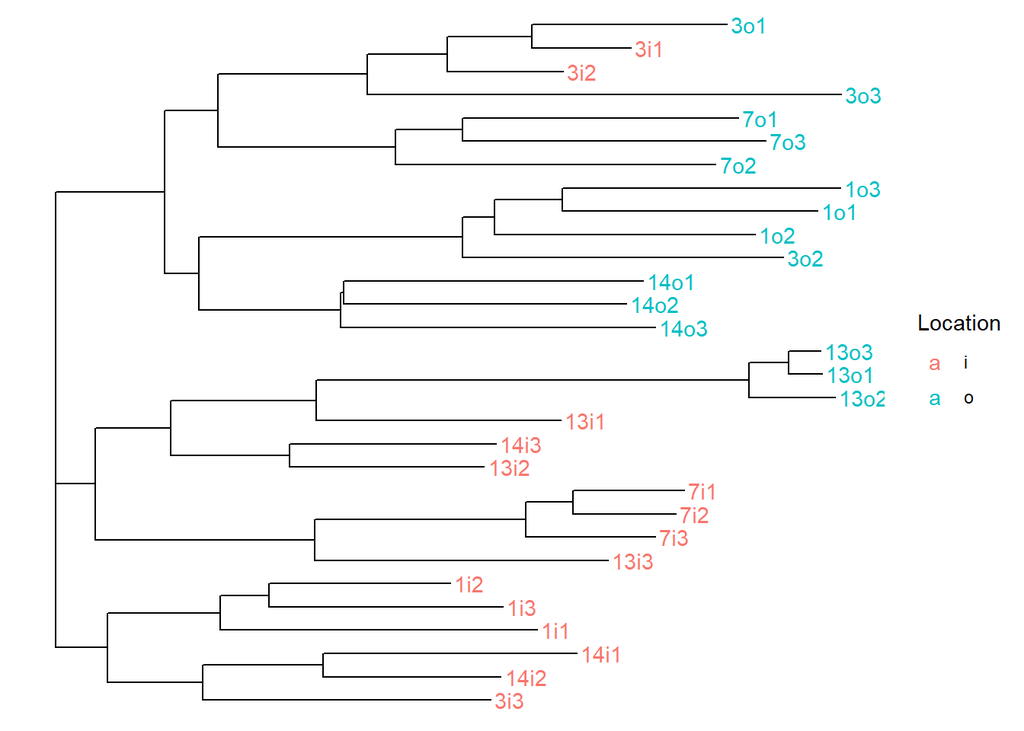

```r
ggtree(tree, layout = "rectangular") %<+% FS +
geom_tiplab(aes(colour=Location)) + theme(legend.position = "right")
```

Figure 1: Tree of different quadrates. i indicates that the quadrate patch is inside garlic mustard patches, and o indicates that the quadrate patch is outside the garlic mustard patches. We can see this because the quadrates coloured for i and o are in almost entirely separate clades, except for 13o3, 13o1, 13o2, 3i1, and 3i2. Therefore, this figure demonstrates that garlic mustard has a large effect on the plant community.

## Analysis

Based on the results seen in Figure 1, we can conclude that garlic mustard has a large effect on the plant community. This is because the quadrates coloured for i and o are in almost entirely separate clades, except for 13o3, 13o1, 13o2, 3i1, and 3i2. Due to the small number of outlying quadrates, they are likely located in their positions due to some other property, such as bolding or budding, which, when not accounted for, would likely cause the outliers to move into their respective clades. This finding would further indicate that garlic mustard has a large effect on the plant community.

# Question 2

## NMDS

```r
set.seed(13)
NMDSdat=metaMDS(dist, k=2, trymax = 100)
```

```
## *** Best solution repeated 1 times
```

## Create data for plotting

```r
row.names(FS)=FS$Quadrate
row.names(FS)
```

```
##  [1] "7o3"  "7o1"  "7o2"  "7i3"  "7i2"  "7i1"  "3i1"  "3i2"  "3i3"  "3o1"
## [11] "3o2"  "3o3"  "1i3"  "1i2"  "1i1"  "1o1"  "1o2"  "1o3"  "13o1" "13o2"
## [21] "13o3" "13i2" "13i1" "13i3" "14o2" "14o1" "14o3" "14i2" "14i1" "14i3"
```

```r
PDat=data.frame(NMDS1=NMDSdat$points[,1],
                NMDS2=NMDSdat$points[,2],
                Quadrate=row.names(FS))
```

## Add labels

```r
PDat=merge(PDat, FS, by="Quadrate", all.x=T, all.y =F)
```

## Plot

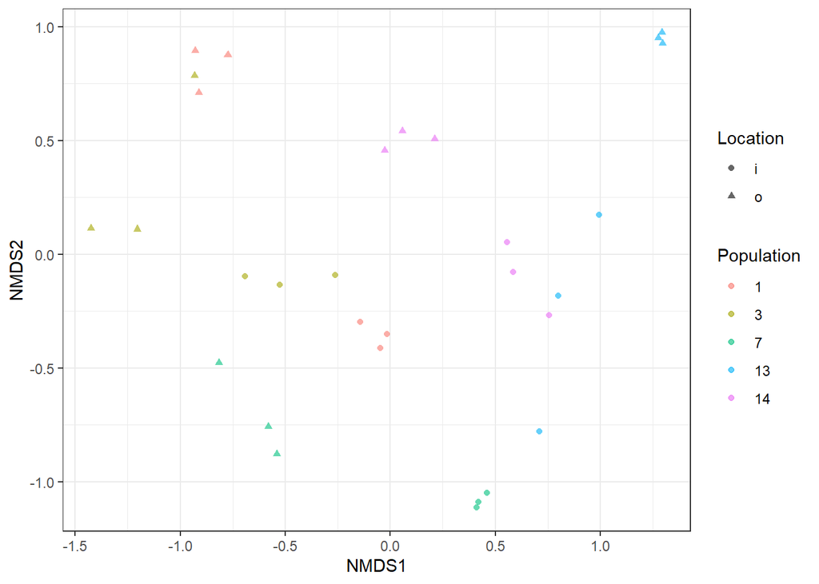

```r
PDat$Population=as.factor(PDat$Population)
qplot(x=NMDS1, NMDS2, alpha=I(0.6), data = PDat, shape=Location, colour=Population)+theme_bw()
```

Figure 2: NMDS Plot. i indicates that the quadrate patch is inside garlic mustard patches, and o indicates that the quadrate patch is outside the garlic mustard patches. This figure demonstrates the distinction of samples based on location and population and shows that the locations are well-clustered and divided across the 45-degree line. We can also see that the populations are not as well clustered, with different colours located sporadically across the plot.

## Analysis

Based on the results seen in Figure 2, we can conclude that the presence/absence of garlic mustard (location: in(i)/out(o)) has a stronger effect on plant communities than the sampling population. This is seen because the presence/absence of garlic mustard is well clustered and divided across the 45-degree line, with a few deviants. In contrast, populations are not clustered as well, as different colours are located sporadically across the plot.